## BIOL5081: Biostatistics GradeR

[figure not shown]

The goal of the [graduate-level course](https://cjlortie.github.io/r.stats/) was statistical thinking through R and good data science. Data frames, EDA, and effective graphics can enhance our capacity to use statistical thinking to solve problems and examine evidence. Real data were used to both practice, time-bounded code (hackathon model), and follow-up revise workflow and analyses.

The purpose of this workflow is to explore whether the philosophy effectively translated into learning and evaluation. The evidence examined were the test scores from each iteration.

**Meta-data for scoring dimensions** A total of 25% so 5 questions each worth 5 points. Likert Scale of 1 to 5 with 1 being low and 5 being awesome. The book [‘The Art of Data Science’](https://leanpub.com/artofdatascience) by Peng and Metsui was extremely helpful. In particular, the EDA checklist provided in chapter 4.

- Can I understand what was done?
- Can I repeat what was done?
- Does the data viz effectively and thoroughly examine and show patterns/relations?
- Is the EDA a clear and appropriate examination the evidence and demonstrates statistical thinking?
- Is the final graphic and statistical test appropriate (tidy, polished, and meaningful) and suitable for publication?

### Time-bounded hackathon

```r
library(dplyr)
```

```r
library(ggplot2)
library(tibble)
library(knitr)
library(fitdistrplus)
#read data
metrics <-read.csv('data/BIOL5081.2016.grades.csv')
#as_tibble(metrics)
hackathon <- metrics %>% filter(metric == "test1")

#table so people can see their scores
kable(hackathon)
```

| abbrev.id | metric | dataset | comprehensiblility | reproduciblity | vizualization | EDA | statistical.merit | total |
| --- | --- | --- | --- | --- | --- | --- | --- | --- |
| 8867 | test1 | happiness | 4 | 4 | 4 | 5 | 4 | 21 |
| 5963 | test1 | flossing | 5 | 5 | 5 | 5 | 4 | 24 |
| 2253 | test1 | green.roofs | 5 | 4 | 5 | 4 | 4 | 22 |
| 5290 | test1 | education.value | 3 | 3 | 4 | 3 | 4 | 17 |
| 7585 | test1 | education.value | 3 | 3 | 4 | 3 | 4 | 17 |
| 2220 | test1 | paris.agreement | 3 | 4 | 4 | 3 | 4 | 18 |
| 9292 | test1 | happiness | 4 | 3 | 4 | 4 | 3 | 18 |
| 7666 | test1 | happiness | 4 | 5 | 4 | 4 | 4 | 21 |
| 7710 | test1 | running.records | 5 | 5 | 4 | 4 | 4 | 22 |
| 7836 | test1 | happiness | 4 | 5 | 4 | 5 | 4 | 22 |
| 2167 | test1 | green.roofs | 4 | 4 | 3 | 3 | 3 | 17 |
| 8473 | test1 | green.roofs | 5 | 5 | 4 | 4 | 5 | 23 |
| 6030 | test1 | happiness | 3 | 4 | 4 | 3 | 4 | 18 |
| 9741 | test1 | happiness | 4 | 5 | 5 | 4 | 5 | 23 |
| 8533 | test1 | education.value | 5 | 5 | 5 | 4 | 5 | 24 |
| 1345 | test1 | running.records | 3 | 4 | 4 | 4 | 3 | 18 |
| 4125 | test1 | flossing | 5 | 5 | 4 | 4 | 5 | 23 |
| 8675 | test1 | running.records | 3 | 4 | 3 | 3 | 4 | 17 |
| 1164 | test1 | flossing | 3 | 5 | 5 | 4 | 4 | 21 |
| 8202 | test1 | happiness | 4 | 5 | 4 | 4 | 4 | 21 |

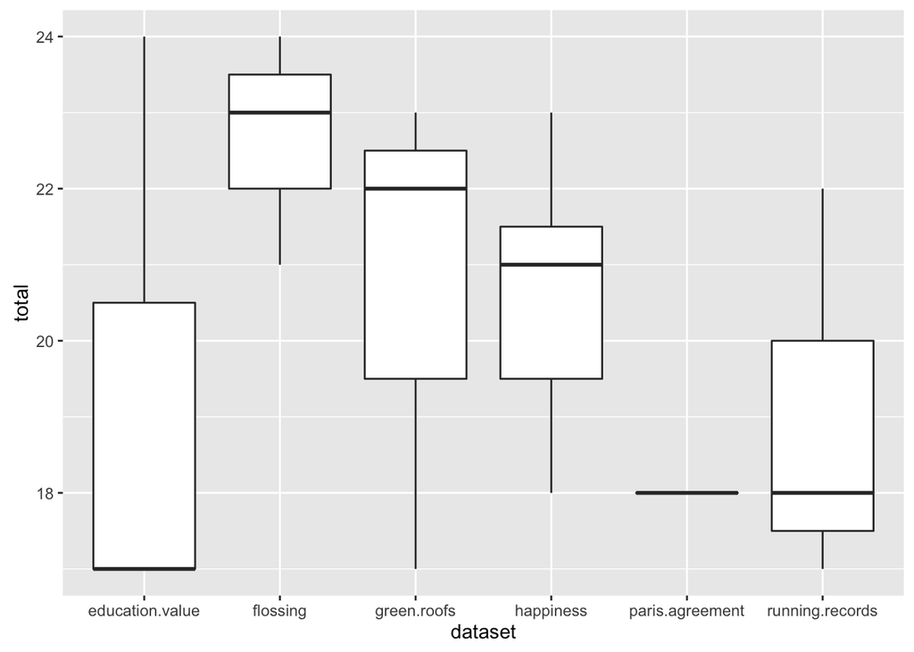

```r
#data viz for pattern analysis and exploration of potential stats
ggplot(hackathon, aes(dataset, total)) +
  geom_boxplot()
```

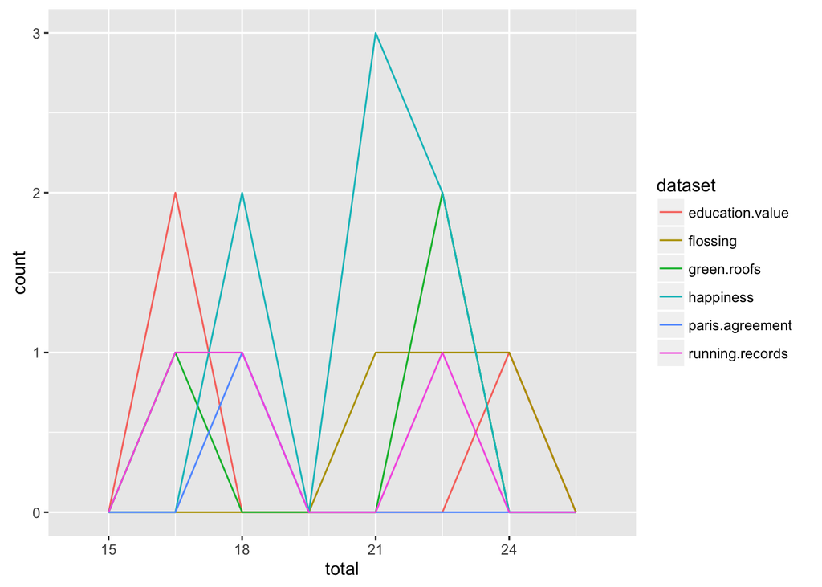

```r
ggplot(hackathon, aes(total, colour = dataset)) +
         geom_freqpoly(binwidth = 1.5)
```

```r
#EDA on distribution
shapiro.test(hackathon$total)
```

```
##
##  Shapiro-Wilk normality test
##
## data:  hackathon$total
## W = 0.87144, p-value = 0.01245
```

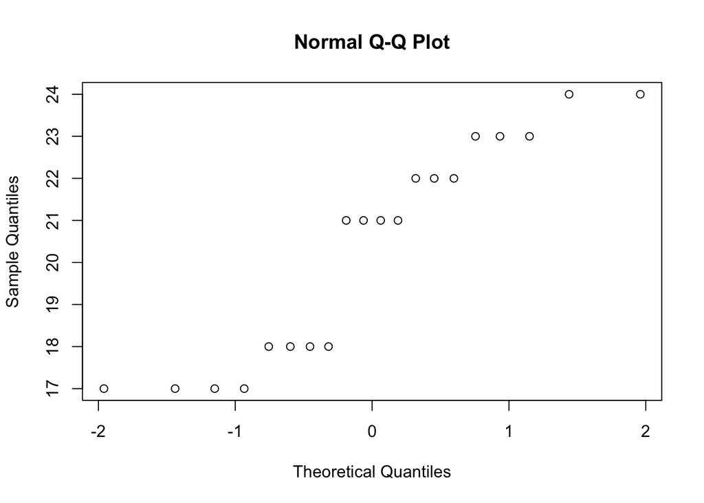

```r
qqnorm(hackathon$total)
```